# HW5 : 석사 2학기 이동규

#### **Library**

```r
library(boot) #chapter8
library(MASS) #chapter16
library(FactoMineR) #chapter16
library(gclus) #chapter17
library(e1071) #chapter17
library(kernlab) #chapter17
library(rpart) #chapter18
library(randomForest) #chapter18
library(ipred) #chapter18
```

# 8장 붓스트랩 방법

### [붓스트랩 사례: 상관계수]

```r
x <- c(15,26,10,9,15,20,18,11,8,20,7,9,10,11,11,10,12,17,11,10)
y <- c(95,71,83,91,102,87,93,100,104,94,113,96,83,84,102,100,105,121,86,100)
cor.X <- function(data, indices) cor(data[indices,1],data[indices,2])

boot.log <- boot(data=cbind(x,y), statistic=cor.X, R=1000)
print(boot.log)
```

```
##
## ORDINARY NONPARAMETRIC BOOTSTRAP
##
##
## Call:
## boot(data = cbind(x, y), statistic = cor.X, R = 1000)
##
##
## Bootstrap Statistics :
##       original     bias    std. error
## t1* -0.3349073 0.04334141   0.2733199
```

우리는 상관계수에 대한 추정치의 신뢰구간 및 표준편차, 편향을 구하기 위해 붓스트랩을 시행하였다. 붓스트랩은 1000번 시행하였으며, 그값은 위에 제시되어 있다. 또한, original은 추정치 값으로 원래 데이터에서 구할 수 있다.

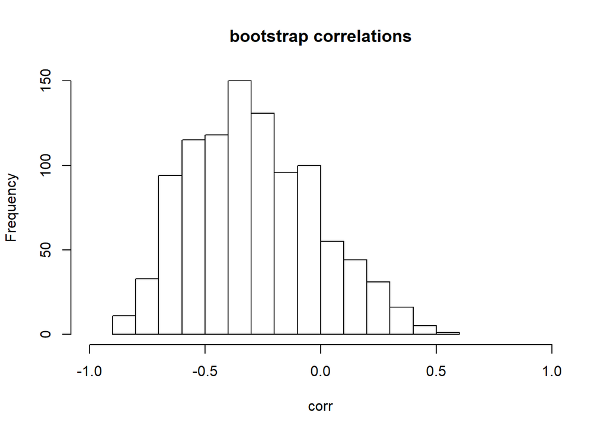

```r
hist(boot.log$t, xlim=c(-1,1), nclass=20, main="bootstrap correlations", xlab="corr")
```

```r
boot.ci(boot.log, type = c("perc", "bca"))
```

```
## BOOTSTRAP CONFIDENCE INTERVAL CALCULATIONS
## Based on 1000 bootstrap replicates
##
## CALL :
## boot.ci(boot.out = boot.log, type = c("perc", "bca"))
##
## Intervals :
## Level     Percentile            BCa
## 95%   (-0.7372,  0.2903 )   (-0.7988,  0.2309 )
## Calculations and Intervals on Original Scale
```

그리고 히스토그램을 그렸을 때, 분포는 비 대칭적인 형태를 띠고있다. 그러므로, BCa 신뢰구간을 읽어주는 것이 좋다. BCa방법과 Percentile방법으로 얻은 추정치의 신뢰구간은 위에서 확인할 수 있다.  
###[붓스트랩 사례: 회귀분석]

```r
data(Affairs, package = "AER")
str(Affairs)
```

```
## 'data.frame':    601 obs. of  9 variables:
##  $ affairs      : num  0 0 0 0 0 0 0 0 0 0 ...
##  $ gender       : Factor w/ 2 levels "female","male": 2 1 1 2 2 1 1 2 1 2 ...
##  $ age          : num  37 27 32 57 22 32 22 57 32 22 ...
##  $ yearsmarried : num  10 4 15 15 0.75 1.5 0.75 15 15 1.5 ...
##  $ children     : Factor w/ 2 levels "no","yes": 1 1 2 2 1 1 1 2 2 1 ...
##  $ religiousness: int  3 4 1 5 2 2 2 2 4 4 ...
##  $ education    : num  18 14 12 18 17 17 12 14 16 14 ...
##  $ occupation   : int  7 6 1 6 6 5 1 4 1 4 ...
##  $ rating       : int  4 4 4 5 3 5 3 4 2 5 ...
```

이번에는 [붓스트랩 사례: 로지스틱 회귀]에 대해 알아본다. Affairs 데이터 구조는 위와 같다. 그리고 반응변수로 ynaffair , 설명변수로 gender, age, yearsmarried, religiousness, rating을 선택한다. 이때 ynaffair은 afaairs변수를 가지고 만들며 1이상이면 1 , 0이면 0을 갖는 이항형 반응변수이다.

```r
Affairs$ynaffair[Affairs$affairs > 0] <- 1
Affairs$ynaffair[Affairs$affairs == 0] <- 0
# Affairs$ynaffair <- factor(Affairs$ynaffair, levels = c(0,1), labels = c("No", "Yes"))
logistic.model <- glm(ynaffair ~ gender + age + yearsmarried + religiousness + rating, family=binomial(), data = Affairs)
summary(logistic.model)
```

```
##
## Call:
## glm(formula = ynaffair ~ gender + age + yearsmarried + religiousness +
##     rating, family = binomial(), data = Affairs)
##
## Deviance Residuals:
##     Min       1Q   Median       3Q      Max
## -1.5623  -0.7495  -0.5664  -0.2671   2.3975
##
## Coefficients:
##               Estimate Std. Error z value Pr(>|z|)
## (Intercept)    1.94760    0.61234   3.181 0.001470 **
## gendermale     0.38612    0.20703   1.865 0.062171 .
## age           -0.04393    0.01806  -2.432 0.015011 *
## yearsmarried   0.11133    0.02983   3.732 0.000190 ***
## religiousness -0.32714    0.08947  -3.656 0.000256 ***
## rating        -0.46721    0.08928  -5.233 1.67e-07 ***
## ---
## Signif. codes:  0 '***' 0.001 '**' 0.01 '*' 0.05 '.' 0.1 ' ' 1
##
## (Dispersion parameter for binomial family taken to be 1)
##
##     Null deviance: 675.38  on 600  degrees of freedom
## Residual deviance: 611.86  on 595  degrees of freedom
## AIC: 623.86
##
## Number of Fisher Scoring iterations: 4
```

그리고 이를 통해 로지스틱 회귀분석을 적용하면 위의 결과와 같다. 우리는 위 추정치에 대해 붓스트랩방법을 사용하여 편향과 붓스트랩 표준편차를 계산하려고 한다.

```r
coefs <- function(data, indices, formula) {
  data.1 <- data[indices, ]
  fit <- glm(formula, data = data.1, family=binomial())
  return(coef(fit))
}
logistic.log <- boot(data = Affairs, statistic = coefs, R = 1000, formula = ynaffair ~ gender + age + yearsmarried + religiousness + rating)
print(logistic.log, index=1:6, digits=2)
```

```
##
## ORDINARY NONPARAMETRIC BOOTSTRAP
##
##
## Call:
## boot(data = Affairs, statistic = coefs, R = 1000, formula = ynaffair ~
##     gender + age + yearsmarried + religiousness + rating)
##
##
## Bootstrap Statistics :
##     original   bias    std. error
## t1*    1.948  0.03468       0.658
## t2*    0.386 -0.00032       0.215
## t3*   -0.044 -0.00107       0.020
## t4*    0.111  0.00255       0.031
## t5*   -0.327 -0.00418       0.094
## t6*   -0.467 -0.00600       0.087
```

###[붓스트랩 사례: 두 독립표본의 중심 간 차이]

```r
set.seed(123)
x <- rgamma(100,5,0.8)
y <- rgamma(100,5,1.0)
x.and.y <- data.frame(x, y)
z <- stack(x.and.y)
t.test(x, y, var.equal=T)
```

```
##
##  Two Sample t-test
##
## data:  x and y
## t = 3.6788, df = 198, p-value = 0.000302
## alternative hypothesis: true difference in means is not equal to 0
## 95 percent confidence interval:
##  0.5650153 1.8706557
## sample estimates:
## mean of x mean of y
##  5.940007  4.722172
```

이번엔 두 독립표본의 중심간의 차이에 대해 붓스트랩 하는 방법을 알아보자. 먼저 two sample t-test를 시행하면 위의 결과와 같다.

```r
diff.means <- function(data, n1, indices) {
  m1 <- mean(data[indices[indices <= n1],1])
  m2 <- mean(data[indices[indices >  n1],1])
  c(m1 - m2)
}

z.boot <- boot(data=z, statistic=diff.means, n1=100, R=1000, strata=z[,2])
boot.ci(z.boot, type = c("perc", "bca"))
```

```
## BOOTSTRAP CONFIDENCE INTERVAL CALCULATIONS
## Based on 1000 bootstrap replicates
##
## CALL :
## boot.ci(boot.out = z.boot, type = c("perc", "bca"))
##
## Intervals :
## Level     Percentile            BCa
## 95%   ( 0.568,  1.861 )   ( 0.570,  1.862 )
## Calculations and Intervals on Original Scale
```

그리고 이어서 붓스트랩을 적용한 결과이다. strata=z[,2]는 표본별로 복원추출을 하라는 옵션의미이다. 그리고 얻어진 percentile과 BCa의 두가지 붓스트랩 신뢰구간을 얻을 수 있다.

# 16장 행렬도와 대응분석

### [행렬도]

```r
setwd("C:\\Users\\82104\\Desktop\\대학원 수업\\1학년 2학기\\통계분석방법론\\응용데이터분석\\Applied Data Analysis Using R\\Applied Data Analysis Using R\\16_biplot and correspondence analysis")

# r biplot for protein data

X.1 <- read.table("protein.txt",header=T)
str(X.1)
```

```
## 'data.frame':    25 obs. of  10 variables:
##  $ Country: Factor w/ 25 levels "Albania","Austria",..: 1 2 3 4 5 6 7 8 9 10 ...
##  $ Beef   : num  10.1 8.9 13.5 7.8 9.7 10.6 8.4 9.5 18 10.2 ...
##  $ Chicken: num  1.4 14 9.3 6 11.4 10.8 11.6 4.9 9.9 3 ...
##  $ Egg    : num  0.5 4.3 4.1 1.6 2.8 3.7 3.7 2.7 3.3 2.8 ...
##  $ Milk   : num  8.9 19.9 17.5 8.3 12.5 25 11.1 33.7 19.5 17.6 ...
##  $ Fish   : num  0.2 2.1 4.5 1.2 2 9.9 5.4 5.8 5.7 5.9 ...
##  $ Cereal : num  42.3 28 26.6 56.7 34.3 21.9 24.6 26.3 28.1 41.7 ...
##  $ Potato : num  0.6 3.6 5.7 1.1 5 4.8 6.5 5.1 4.8 2.2 ...
##  $ Bean   : num  5.5 1.3 2.1 3.7 1.1 0.7 0.8 1 2.4 7.8 ...
##  $ Fruit  : num  1.7 4.3 4 4.2 4 2.4 3.6 1.4 6.5 6.5 ...
```

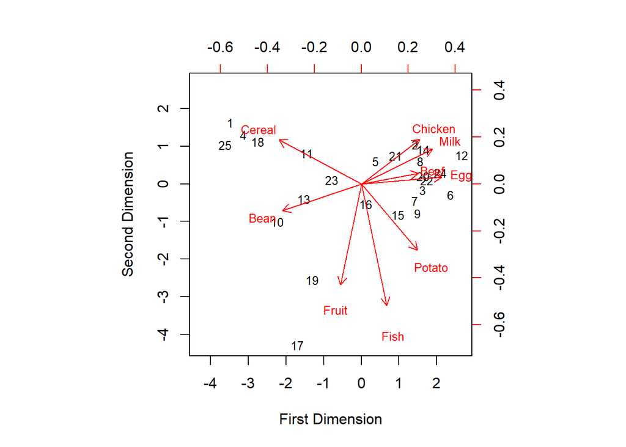

```r
X <- X.1[,2:10]
n <- nrow(X)

# Using R function princomp()
pca.X <- princomp(X, cor=T)
pca.X$scores <- pca.X$scores*sqrt((n-1)/n)
# round(pca.X$scores,3)
# round(apply(pca.X$scores,2,sd),3)
biplot(pca.X,scale=0,cex=0.8,xlab="First Dimension",ylab="Second Dimension")
```

```r
X.1$Country
```

```
##  [1] Albania    Austria    Bel-Luxem  Bulgaria   Czecho     Denmark
##  [7] E-Germany  Finland    France     Greece     Hungary    Ireland
## [13] Italy      Netherland Norway     Poland     Portugal   Rumania
## [19] Spain      Sweden     Swiss      U-Kingdom  USSR       W-Germany
## [25] Yugoslavia
## 25 Levels: Albania Austria Bel-Luxem Bulgaria Czecho Denmark ... Yugoslavia
```

위처럼 작성하면 행렬도를 얻어낼 수 있다. 또한 행렬도에서 개체번호와 국가이름의 연결은 위와 같다. 다음은 주성분 분석의 요약이다.

```r
summary(pca.X,loadings=T)
```

```
## Importance of components:
##                           Comp.1    Comp.2    Comp.3    Comp.4    Comp.5
## Standard deviation     2.0016087 1.2786710 1.0620355 0.9770691 0.6810568
## Proportion of Variance 0.4451597 0.1816666 0.1253244 0.1060738 0.0515376
## Cumulative Proportion  0.4451597 0.6268263 0.7521507 0.8582245 0.9097621
##                            Comp.6     Comp.7     Comp.8     Comp.9
## Standard deviation     0.57020257 0.52115865 0.34101599 0.31482043
## Proportion of Variance 0.03612566 0.03017848 0.01292132 0.01101243
## Cumulative Proportion  0.94588776 0.97606624 0.98898757 1.00000000
##
## Loadings:
##         Comp.1 Comp.2 Comp.3 Comp.4 Comp.5 Comp.6 Comp.7 Comp.8 Comp.9
## Beef     0.303         0.298  0.646  0.322  0.460  0.150         0.246
## Chicken  0.311  0.237 -0.624        -0.300  0.121                0.592
## Egg      0.427        -0.182  0.313        -0.361 -0.443  0.491 -0.333
## Milk     0.378  0.185  0.386        -0.200 -0.618  0.462         0.178
## Fish     0.136 -0.647  0.321 -0.216 -0.290  0.137 -0.106  0.449  0.313
## Cereal  -0.438  0.233                0.238         0.405  0.703  0.152
## Potato   0.297 -0.353 -0.243 -0.337  0.736 -0.148  0.153 -0.115  0.122
## Bean    -0.420 -0.143         0.330  0.151 -0.447 -0.407 -0.184  0.518
## Fruit   -0.110 -0.536 -0.408  0.462 -0.234 -0.119  0.450        -0.203
```

표준편차와 분산비, 누적분산값을 볼 있으며 이에대한 loading(계수벡터) 값도 볼 수 있다.

### [대응분석]

```r
# Correspondence analysis for 2007 Presidential Election Survey data

F0 <- read.table("C:\\Users\\82104\\Desktop\\대학원 수업\\1학년 2학기\\통계분석방법론\\응용데이터분석\\Applied Data Analysis Using R\\Applied Data Analysis Using R\\16_biplot and correspondence analysis\\election.txt", header=T)
F <- as.matrix(F0[,-1])
rownames(F) <- F0[,1]
addmargins(F)
```

```
##        dw  mb  hc  kh etc  dk  Sum
## SL     42 170  35  22   8  51  328
## PK     21 108  33  15  11  53  241
## TK     13  94  30   6   3  21  167
## KG     57 182  49  34  25  64  411
## KJ     72  18   6  19  12  34  161
## DC     19  53  31  11   8  31  153
## KJeju   7  17   8   3   4  22   61
## Sum   231 642 192 110  71 276 1522
```

```r
r.margin <- addmargins(F)[,7]
c.margin <- addmargins(F)[8,]
```

위의 결과는 대응분석 데이터이다.

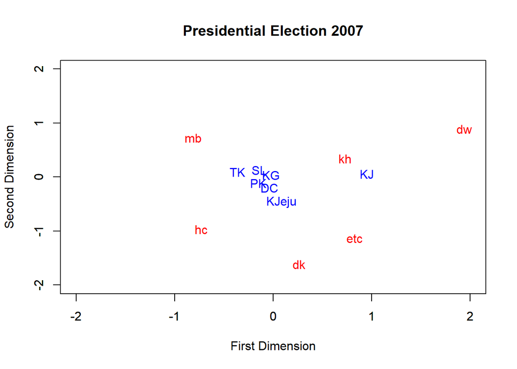

```r
corresp.F <- corresp(F,nf=2)
attach(corresp.F)
ROW <- rscore%*%diag(cor)
COL <- cscore
plot(ROW[,2]~ROW[,1],type="n",xlim=c(-2,2),ylim=c(-2,2),xlab="First Dimension",ylab="Second Dimension",main="Presidential Election 2007")
text(ROW[,1],ROW[,2],labels=rownames(ROW),cex=1,col="blue")
par(new=T)
plot(COL[,2]~COL[,1],type="n",xlim=c(-2,2),ylim=c(-2,2),xlab="",ylab="")
text(COL[,1],COL[,2],labels=rownames(COL),cex=1,col="red")
```

그리고 가중 표현 없이 평면에 펼쳐진 대응분석 그래프를 그리면 위와 같다. 그리고 심플렉스에 각 꼭지점에 해당하는 빨간색 점들과 파란색 점들이 얼마나 유사한지를 확인할 수 있다. 다만 크기가 반영이 되어있지 않다는 점에서 아래와 같이 빈도를 가중치로 하여 대응분석을 다시 할 수 있다.

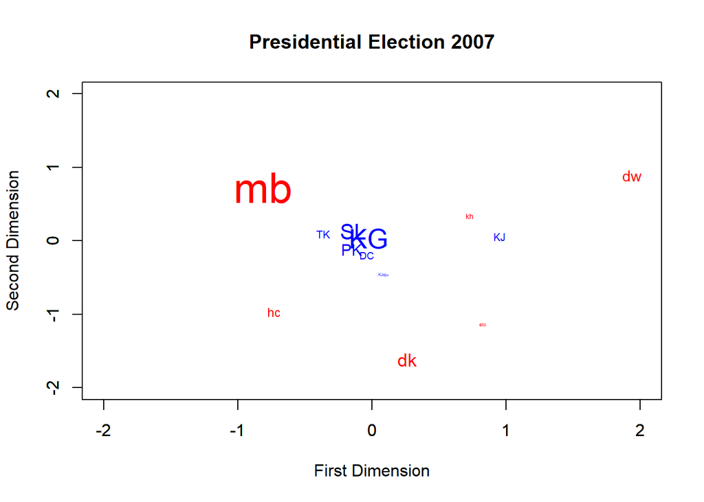

```r
plot(ROW[,2]~ROW[,1],type="n",xlim=c(-2,2),ylim=c(-2,2),xlab="First Dimension",ylab="Second Dimension",main="Presidential Election 2007")
text(ROW[,1],ROW[,2],labels=rownames(ROW),cex=r.margin/sum(r.margin)*12,col="blue")
par(new=T)
plot(COL[,2]~COL[,1],type="n",xlim=c(-2,2),ylim=c(-2,2),xlab="",ylab="")
text(COL[,1],COL[,2],labels=rownames(COL),cex=c.margin/sum(c.margin)*12,col="red")
```

해석은 위에서 했던것과 마찬가지로 진행된다. 행범주와 열범주의 크기를 표현한 결과이다.

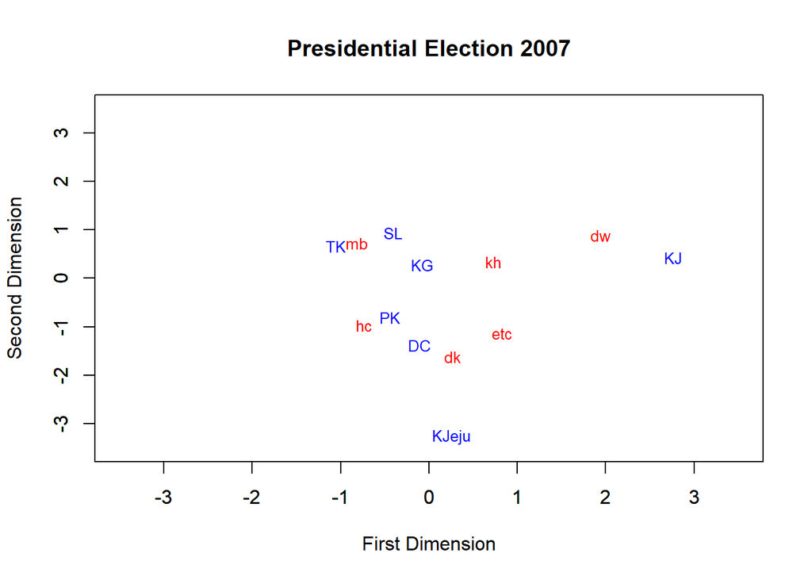

```r
par(mfrow=c(1,1))
plot(rscore[,2]~rscore[,1],type="n",xlim=c(-3.5,3.5),ylim=c(-3.5,3.5),xlab="First Dimension",ylab="Second Dimension",main="Presidential Election 2007")
text(rscore[,1],rscore[,2],labels=rownames(rscore),cex=0.8,col="blue")
par(new=T)
plot(cscore[,2]~cscore[,1],type="n",xlim=c(-3.5,3.5),ylim=c(-3.5,3.5),xlab="",ylab="")
text(cscore[,1],cscore[,2],labels=rownames(cscore),cex=0.8,col="red")
```

또한 대칭적 대응분석을 위해 plot을 그린 그림이다. 행과 열이 대칭인경우 행변수와 열변수간 상관의 최대화에 분석목표를 두게 된다.

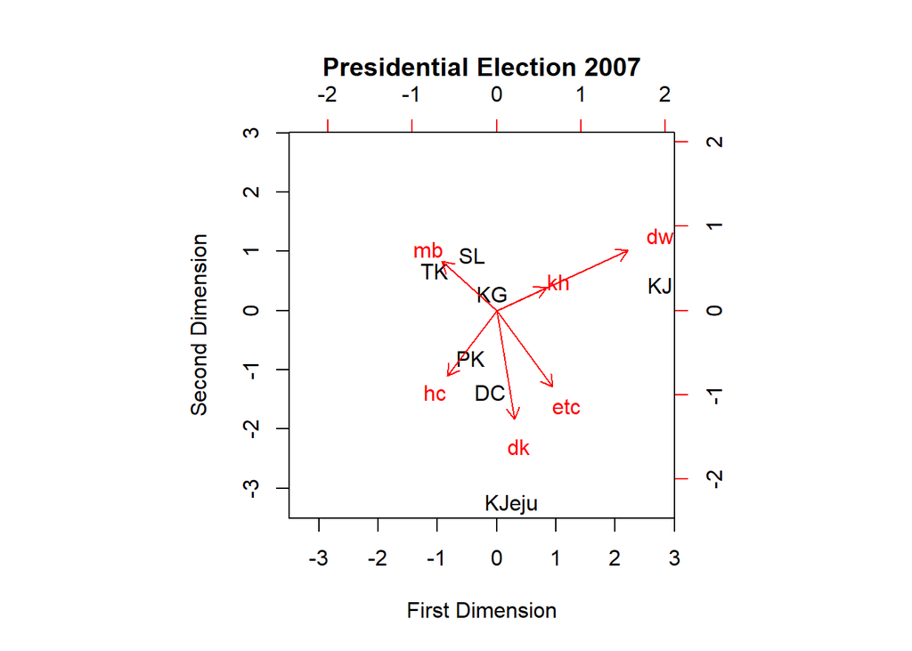

```r
# Alternative Biplot
biplot(rscore,cscore,cex=1,xlab="First Dimension",ylab="Second Dimension",main="Presidential Election 2007")
```

그리고 대칭형 대응분석을 위를 통해 시행할 수 있다.

### [다중대응분석]

다음은 다중대응분석에 대한 이야기이다. 다중대응분석은 범주형의 PCA버전이다. 먼저 tea데이터에서 선별한 변수의 데이터 구조는 아래와 같다.

```r
data(tea)
tea.1 <- tea[,c("Tea","How","sugar","how","where","always")]
str(tea.1)
```

```
## 'data.frame':    300 obs. of  6 variables:
##  $ Tea   : Factor w/ 3 levels "black","Earl Grey",..: 1 1 2 2 2 2 2 1 2 1 ...
##  $ How   : Factor w/ 4 levels "alone","lemon",..: 1 3 1 1 1 1 1 3 3 1 ...
##  $ sugar : Factor w/ 2 levels "No.sugar","sugar": 2 1 1 2 1 1 1 1 1 1 ...
##  $ how   : Factor w/ 3 levels "tea bag","tea bag+unpackaged",..: 1 1 1 1 1 1 1 1 2 2 ...
##  $ where : Factor w/ 3 levels "chain store",..: 1 1 1 1 1 1 1 1 2 2 ...
##  $ always: Factor w/ 2 levels "always","Not.always": 2 2 2 2 1 2 2 2 2 2 ...
```

또한 아래와 같이 tea데이터에 대해 다중대응분석 그래프를 그리면 아래와 같다. 17개의 빨간 점들이 찍히며, 행점은 회색으로, 열범주는 빨간색으로 찍혀있다.

```r
mca.tea.1 <- mca(tea.1, nf=2, abbrev=T)
mca.tea.1
```

```
## Call:
## mca(df = tea.1, nf = 2, abbrev = T)
##
## Multiple correspondence analysis of 300 cases of 6 factors
##
## Correlations 0.529 0.508  cumulative % explained 10.58 20.73
```

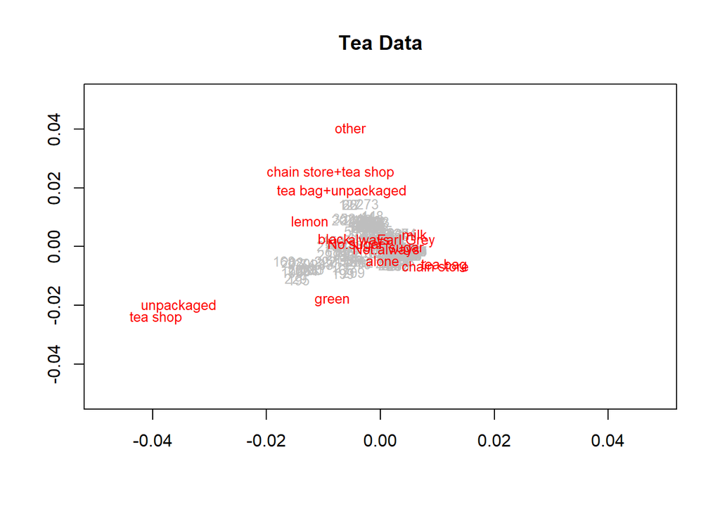

```r
windows(heigh=8,width=7)
plot(mca.tea.1,cex=0.8,xlim=c(-0.05,0.05),ylim=c(-0.05,0.05),col=c("gray","red"),main="Tea Data")
```

그리고 아래와 같이 MCA행 프로파일 플롯과 tea 자료의 MCA 열 범주 플롯을 나눠 그릴수 있다.

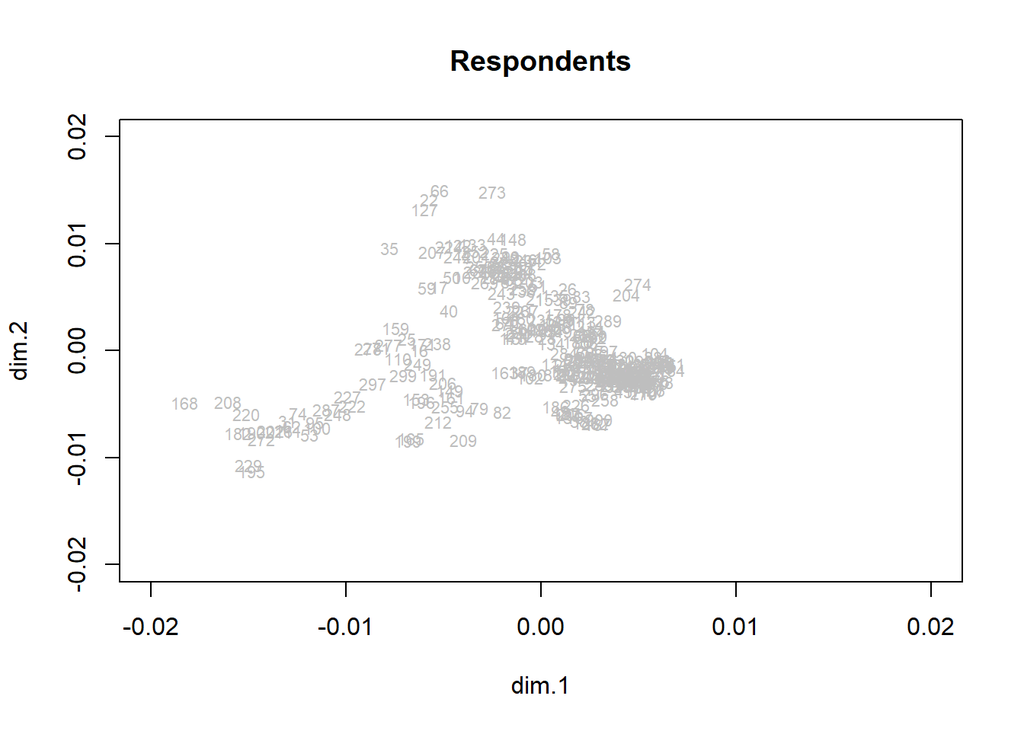

```r
windows(heigh=8,width=7)
plot(mca.tea.1$rs,type="n",xlab="dim.1",ylab="dim.2",xlim=c(-0.02,0.02),ylim=c(-0.02,0.02),main="Respondents")
text(mca.tea.1$rs+matrix(rnorm(600,0,0.0005),300,2),label=1:300,cex=0.7,col="gray")
```

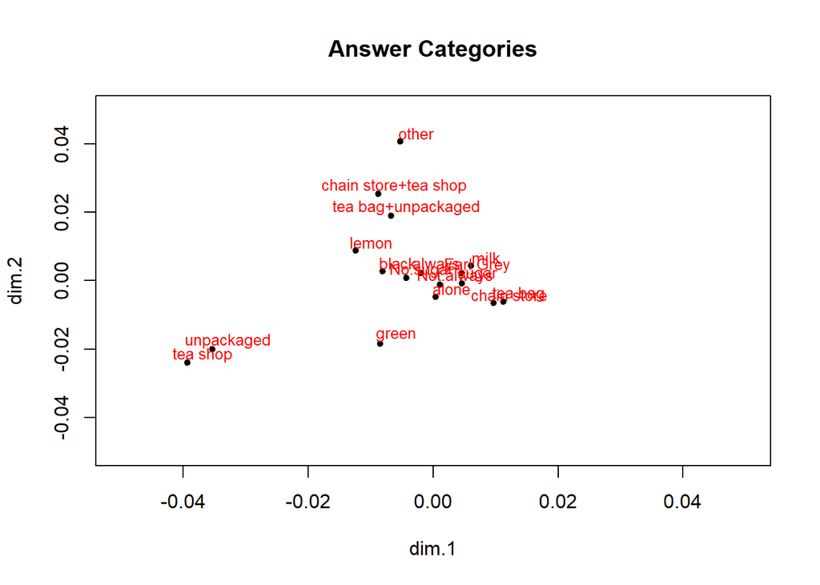

```r
windows(heigh=8,width=7)
plot(mca.tea.1$cs,pch=20,xlab="dim.1",ylab="dim.2",xlim=c(-0.05,0.05),ylim=c(-0.05,0.05),main="Answer Categories")
text(mca.tea.1$cs+0.0025,rownames(mca.tea.1$cs),cex=0.8,col="red")
```

# 17장 SVM

### [비선형 SVM 분류]

```r
# nonlinear classification using SVM

set.seed(123)
x <- matrix(rnorm(200),100,2)
grp <- ifelse(apply(x*x,1,sum) <= 1.16, 1, 2)
y <- as.factor(grp)
table(grp)
```

```
## grp
##  1  2
## 50 50
```

```r
svm.model <- svm(y ~ x, kernel="radial", scale=F, gamma=0.5)
summary(svm.model)
```

```
##
## Call:
## svm(formula = y ~ x, kernel = "radial", gamma = 0.5, scale = F)
##
##
## Parameters:
##    SVM-Type:  C-classification
##  SVM-Kernel:  radial
##        cost:  1
##
## Number of Support Vectors:  41
##
##  ( 20 21 )
##
##
## Number of Classes:  2
##
## Levels:
##  1 2
```

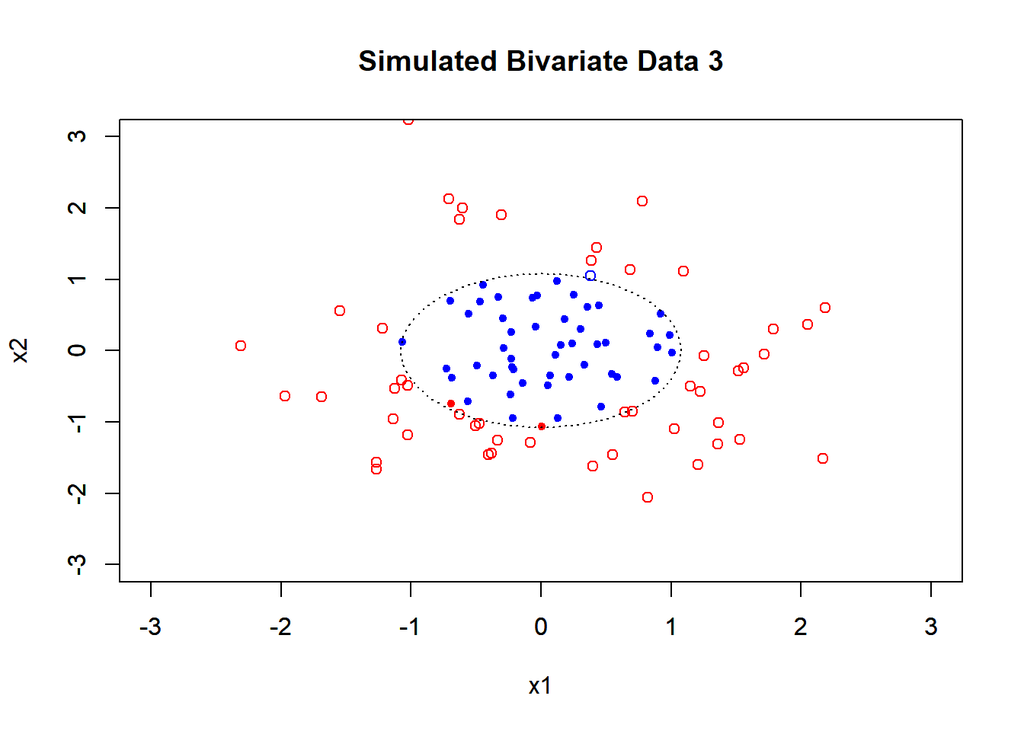

```r
windows(height=8,width=7)
plot(x,pch=c(20,21)[grp],col=c("blue","red")[svm.model$fitted],xlim=c(-3,3),ylim=c(-3,3),main="Simulated Bivariate Data 3",xlab="x1",ylab="x2")
theta <- seq(0,1,0.01)*2*pi
r <- sqrt(1.16)
par(new=T); plot(r*cos(theta),r*sin(theta),lty="dotted",type="l",xlim=c(-3,3),ylim=c(-3,3),xlab="",ylab="")
```

```r
table(svm.model$fitted)
```

```
##
##  1  2
## 49 51
```

비선형 svm 분류를 시행해보자. 데이터는 50, 50개를 생성하였으며, 이를 통해 적합을 시켜 비선형 분류를 시행하면 49, 51개로 매우 분류를 잘 하고 있음을 확인할 수 있다. 감마 모수는 0.5를 주었고, 커널함수로 rbf커널을 사용하였다.

### [스팸 메일 사례]

```r
data(spam); str(spam)
```

```
## 'data.frame':    4601 obs. of  58 variables:
##  $ make             : num  0 0.21 0.06 0 0 0 0 0 0.15 0.06 ...
##  $ address          : num  0.64 0.28 0 0 0 0 0 0 0 0.12 ...
##  $ all              : num  0.64 0.5 0.71 0 0 0 0 0 0.46 0.77 ...
##  $ num3d            : num  0 0 0 0 0 0 0 0 0 0 ...
##  $ our              : num  0.32 0.14 1.23 0.63 0.63 1.85 1.92 1.88 0.61 0.19 ...
##  $ over             : num  0 0.28 0.19 0 0 0 0 0 0 0.32 ...
##  $ remove           : num  0 0.21 0.19 0.31 0.31 0 0 0 0.3 0.38 ...
##  $ internet         : num  0 0.07 0.12 0.63 0.63 1.85 0 1.88 0 0 ...
##  $ order            : num  0 0 0.64 0.31 0.31 0 0 0 0.92 0.06 ...
##  $ mail             : num  0 0.94 0.25 0.63 0.63 0 0.64 0 0.76 0 ...
##  $ receive          : num  0 0.21 0.38 0.31 0.31 0 0.96 0 0.76 0 ...
##  $ will             : num  0.64 0.79 0.45 0.31 0.31 0 1.28 0 0.92 0.64 ...
##  $ people           : num  0 0.65 0.12 0.31 0.31 0 0 0 0 0.25 ...
##  $ report           : num  0 0.21 0 0 0 0 0 0 0 0 ...
```

[output cut: 44 more lines]

```r
svm.model <- svm(type ~ ., data=spam, gamma=1, cost=1)
summary(svm.model)
```

```
##
## Call:
## svm(formula = type ~ ., data = spam, gamma = 1, cost = 1)
##
##
## Parameters:
##    SVM-Type:  C-classification
##  SVM-Kernel:  radial
##        cost:  1
##
## Number of Support Vectors:  3879
##
##  ( 1513 2366 )
##
##
## Number of Classes:  2
##
## Levels:
##  nonspam spam
```

```r
addmargins(table(spam$type, svm.model$fitted))
```

```
##
##           nonspam spam  Sum
##   nonspam    2788    0 2788
##   spam         27 1786 1813
##   Sum        2815 1786 4601
```

```r
n <- nrow(spam)
sub <- sample(1:n, round(0.75*n))
spam.1 <- spam[sub,]
spam.2 <- spam[-sub,]

svm.model.1 <- svm(type ~ ., data=spam.1, gamma=1, cost=1)
summary(svm.model.1)
```

```
##
## Call:
## svm(formula = type ~ ., data = spam.1, gamma = 1, cost = 1)
##
##
## Parameters:
##    SVM-Type:  C-classification
##  SVM-Kernel:  radial
##        cost:  1
##
## Number of Support Vectors:  2989
##
##  ( 1175 1814 )
##
##
## Number of Classes:  2
##
## Levels:
##  nonspam spam
```

```r
addmargins(table(spam.1$type, svm.model.1$fitted))
```

```
##
##           nonspam spam  Sum
##   nonspam    2084    0 2084
##   spam         21 1346 1367
##   Sum        2105 1346 3451
```

하지만 우리는 위보다 다음에 이어질 테스트 데이터에 대한 결과에 더 관심이 많다. 확인하면 아래와 같다.

```r
svm.predict.2 <- predict(svm.model.1, newdata=spam.2)
addmargins(table(spam.2$type, svm.predict.2))
```

```
##          svm.predict.2
##           nonspam spam  Sum
##   nonspam     702    2  704
##   spam        239  207  446
##   Sum         941  209 1150
```

보다시피 총 오류율이 얼마나 과소평가했었는지 실감할 수 있다. 다음은 9가지 모수조합 쌍에서 10cv를 통해 최적의 모수쌍을 찾아보자. 그러면 결과는 아래와 같다. (이 결과는 컴퓨터 성능이 떨어져 데이터가 돌아가는데 시간이 많이 걸립니다. 결과는 생략하겠습니다.)

```r
# tuning
#p.time <- proc.time()
#tune.svm <- tune(svm, type ~ .,  data=spam.1, ranges=list(gamma=c(0.1,1,10),cost=c(0.1,1,10)))
#summary(tune.svm)  # best parameters are 0.1 and 10
#proc.time()-p.time
```

### [선형 SVM회귀]

다음은 모의생성한 2변량 자료에서 선형 svm회귀 에 대해 알아보자. 선형 svm의 개념도에 대한 그림은 아래와 같다.

```r
set.seed(12345)
x <- rnorm(100)
y <- 0.8*x + rnorm(100,0,0.6)  # runif(100,-1,1)
sd(x)
```

```
## [1] 1.114731
```

```r
sd(y)
```

```
## [1] 1.129686
```

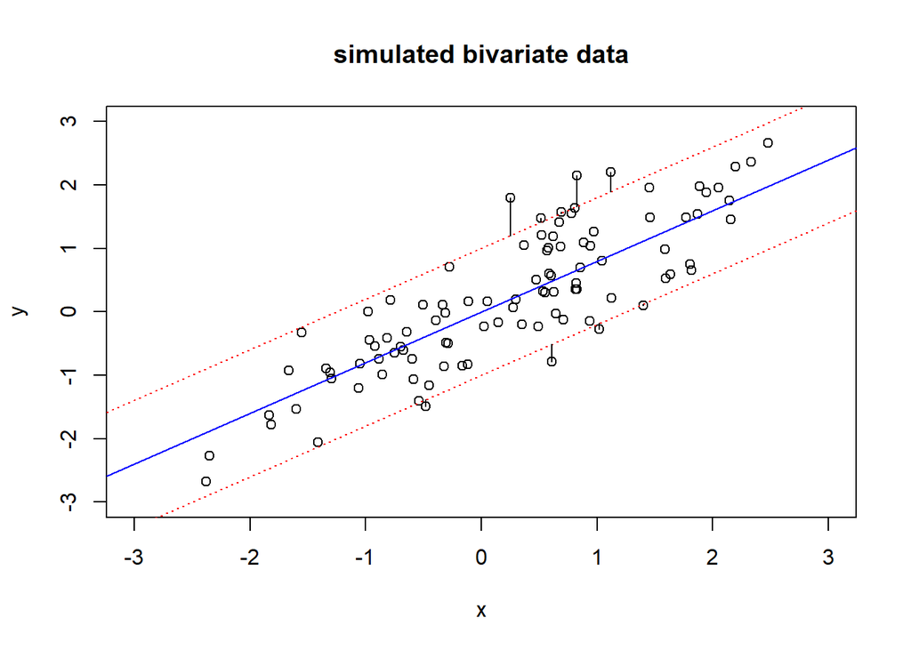

```r
windows(height=7.5,width=7)
plot(y ~ x, main="simulated bivariate data",xlim=c(-3,3),ylim=c(-3,3))
abline(c(0,0.8),col="blue")
abline(c(-1,0.8),col="red",lty="dotted")
abline(c(1,0.8),col="red",lty="dotted")
for (i in 1:100){
  if (y[i]-0.8*x[i] >  1) segments(x[i],y[i],x[i],0.8*x[i]+1)
  if (y[i]-0.8*x[i] < -1) segments(x[i],y[i],x[i],0.8*x[i]-1)
}
```

즉, 바깥에 있는 점들은 이상치로써 간주하고 대략적인 점들의 분포에서 적당한 회귀선을 찾는 것이 svm 선형회귀의 목적이다. 그리고 실제로 svm회귀를 적용시켜 그림을 찾으면 아래와 같이 얻어낼 수 있다.

```r
svm.model <- svm(y ~ x, kernel="linear", epsilon=1, scale=F)  # kernel="radial", epsilon=1, gamma=0.5
summary(svm.model)
```

```
##
## Call:
## svm(formula = y ~ x, kernel = "linear", epsilon = 1, scale = F)
##
##
## Parameters:
##    SVM-Type:  eps-regression
##  SVM-Kernel:  linear
##        cost:  1
##       gamma:  1
##     epsilon:  1
##
##
## Number of Support Vectors:  7
```

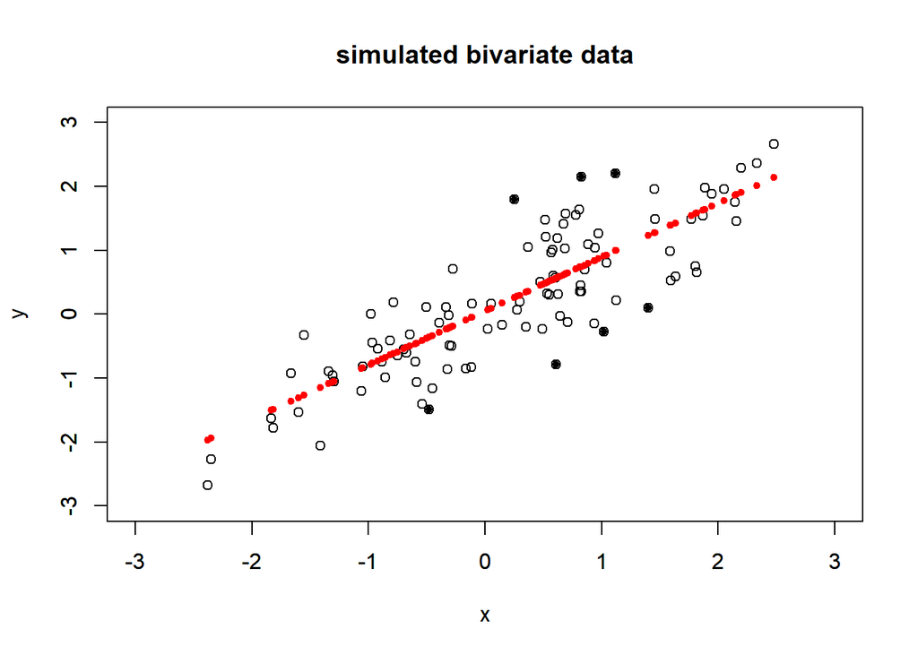

```r
windows(height=7.5,width=7)
plot(y ~ x, main="simulated bivariate data",xlim=c(-3,3),ylim=c(-3,3))
par(new=T)
plot(svm.model$fitted ~ x, main="",xlim=c(-3,3),ylim=c(-3,3),xlab="",ylab="",col="red", pch=20)
points(x[svm.model$index],y[svm.model$index],pch=20)
```

### [비선형 SVM회귀]

그렇다면 이제는 비선형회귀에 대해 알아보자. 데이터의 분포가 곡선패턴을 가지고 있을 때 회귀곡선과 띠의 안팎으로 개념도를 그리면 대략 아래와 같이 그릴 수 있다.

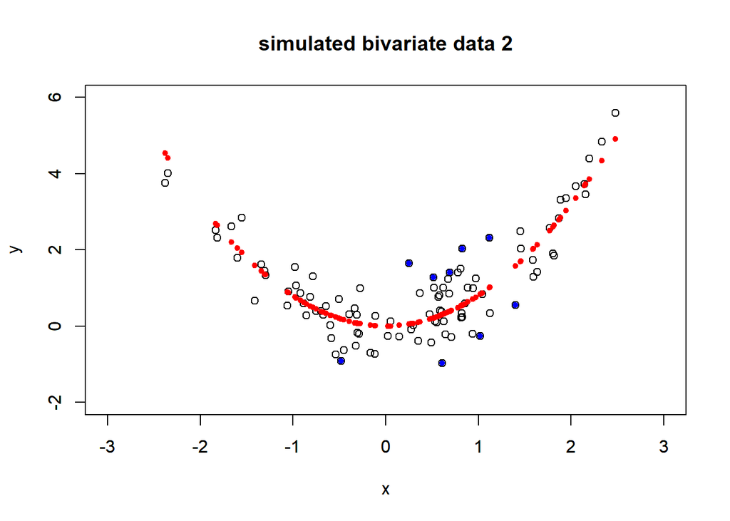

```r
# nonlinear SVM regression

set.seed(12345)
x <- rnorm(100)
y.fit <- 0.8*x^2
y <- y.fit + rnorm(100,0,0.6)  # runif(100,-1,1)

windows(height=7.5,width=7)
plot(y ~ x, main="simulated bivariate data 2",xlim=c(-3,3),ylim=c(-2,6))
par(new=T)
plot(y.fit ~ x, main="",xlim=c(-3,3),ylim=c(-2,6),xlab="",ylab="",col="red", pch=20)
index <- (1:100)[abs(y-y.fit)>=1]
points(x[index],y[index],pch=20,col="blue")
```

그리고 실제 비선형 회귀 svm을 적용시키면 아래와 같이 그릴 수 있다.

```r
svm.model <- svm(y ~ x, gamma=0.5, epsilon=1, scale=F)  # kernel="radial", epsilon=1, gamma=0.5
summary(svm.model)
```

```
##
## Call:
## svm(formula = y ~ x, gamma = 0.5, epsilon = 1, scale = F)
##
##
## Parameters:
##    SVM-Type:  eps-regression
##  SVM-Kernel:  radial
##        cost:  1
##       gamma:  0.5
##     epsilon:  1
##
##
## Number of Support Vectors:  8
```

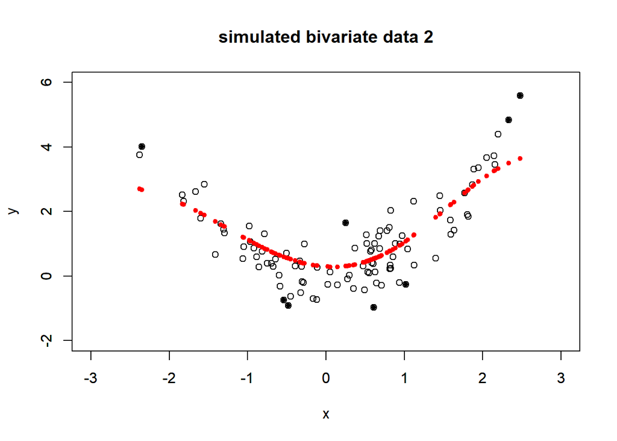

```r
windows(height=7.5,width=7)
plot(y ~ x, main="simulated bivariate data 2",xlim=c(-3,3),ylim=c(-2,6))
par(new=T)
plot(svm.model$fitted ~ x, main="",xlim=c(-3,3),ylim=c(-2,6),xlab="",ylab="",col="red", pch=20)
points(x[svm.model$index],y[svm.model$index],pch=20)
```

검은색으로 채워진 점들은 폭이 $\epsilon=1$인 띠 밖에 있는 개체들이며, 적색점들은 적합한 회귀함수이다. 커널함수는 rbf를 사용하였다.

### [오존 연구사례]

다음은 오존 데이터 사례연구를 살펴보자.

```r
# example 1. Poisson observations
data(ozone)
str(ozone)
```

```
## 'data.frame':    330 obs. of  9 variables:
##  $ Ozone : int  3 5 5 6 4 4 6 7 4 6 ...
##  $ Temp  : int  40 45 54 35 45 55 41 44 54 51 ...
##  $ InvHt : int  2693 590 1450 1568 2631 554 2083 2654 5000 111 ...
##  $ Pres  : int  -25 -24 25 15 -33 -28 23 -2 -19 9 ...
##  $ Vis   : int  250 100 60 60 100 250 120 120 120 150 ...
##  $ Hgt   : int  5710 5700 5760 5720 5790 5790 5700 5700 5770 5720 ...
##  $ Hum   : int  28 37 51 69 19 25 73 59 27 44 ...
##  $ InvTmp: num  47.7 55 57 53.8 54.1 ...
##  $ Wind  : int  4 3 3 4 6 3 3 3 8 3 ...
```

```r
library(e1071)
svm.ozone <- svm(Ozone ~ ., data=ozone, cost=1)
summary(svm.ozone)
```

```
##
## Call:
## svm(formula = Ozone ~ ., data = ozone, cost = 1)
##
##
## Parameters:
##    SVM-Type:  eps-regression
##  SVM-Kernel:  radial
##        cost:  1
##       gamma:  0.125
##     epsilon:  0.1
##
##
## Number of Support Vectors:  250
```

오존데이터를 돌려보면 위와 같다. 그리고 이를 svm에 적용시킨 결과이다. 서포트벡터의 수는 250개, SVM회귀이며 비선형으로 적합하였다.  
그리고 plot을 그리면 아래와 같다.

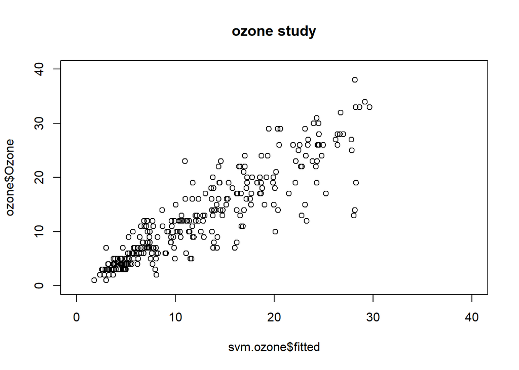

```r
windows(height=7.6, width=7)
plot(ozone$Ozone ~ svm.ozone$fitted, main="ozone study",xlim=c(0,40),ylim=c(0,40))
```

이번엔 10-cv를 통해 최적의 모수 조합을 찾아낸 결과이다. 최고의 모수 조합과 이때의 correlation은 아래에서 확인할 수 있다.

```r
tune.svm <- tune(svm, Ozone ~ ., data=ozone, ranges=list(epsilon=c(0.1,1),gamma=c(0.125,0.5),cost=c(0.1,1)))
summary(tune.svm)
```

```
##
## Parameter tuning of 'svm':
##
## - sampling method: 10-fold cross validation
##
## - best parameters:
##  epsilon gamma cost
##      0.1 0.125    1
##
## - best performance: 15.3685
##
## - Detailed performance results:
##   epsilon gamma cost    error dispersion
## 1     0.1 0.125  0.1 18.34351   5.663240
## 2     1.0 0.125  0.1 34.04196   4.826206
## 3     0.1 0.500  0.1 28.77495   8.851692
## 4     1.0 0.500  0.1 42.57952   7.360594
## 5     0.1 0.125  1.0 15.36850   5.756572
## 6     1.0 0.125  1.0 28.67736   4.084053
## 7     0.1 0.500  1.0 18.26479   5.891493
## 8     1.0 0.500  1.0 37.34381   5.180900
```

```r
cor(svm.ozone$fitted,ozone$Ozone)
```

```
## [1] 0.9056622
```

# 18장 나무알고리즘

### [Kyphosis 사례]

```r
# Tree model via rpart package
# kyophosis data
data(kyphosis)
str(kyphosis)
```

```
## 'data.frame':    81 obs. of  4 variables:
##  $ Kyphosis: Factor w/ 2 levels "absent","present": 1 1 2 1 1 1 1 1 1 2 ...
##  $ Age     : int  71 158 128 2 1 1 61 37 113 59 ...
##  $ Number  : int  3 3 4 5 4 2 2 3 2 6 ...
##  $ Start   : int  5 14 5 1 15 16 17 16 16 12 ...
```

```r
table(kyphosis$Kyphosis)
```

```
##
##  absent present
##      64      17
```

이제 나무알고리즘에 대해 알아보자. 위에서는 kyphosis데이터(분류)를 사용하였으며, 이 데이터는 불균형자료이다. 그리고 나무모형을 가지고 분류를 할 에정이다.

```r
tree.1 <- rpart(Kyphosis ~ Age + Number + Start, data = kyphosis)
tree.1
```

```
## n= 81
##
## node), split, n, loss, yval, (yprob)
##       * denotes terminal node
##
##  1) root 81 17 absent (0.79012346 0.20987654)
##    2) Start>=8.5 62  6 absent (0.90322581 0.09677419)
##      4) Start>=14.5 29  0 absent (1.00000000 0.00000000) *
##      5) Start< 14.5 33  6 absent (0.81818182 0.18181818)
##       10) Age< 55 12  0 absent (1.00000000 0.00000000) *
##       11) Age>=55 21  6 absent (0.71428571 0.28571429)
##         22) Age>=111 14  2 absent (0.85714286 0.14285714) *
##         23) Age< 111 7  3 present (0.42857143 0.57142857) *
##    3) Start< 8.5 19  8 present (0.42105263 0.57894737) *
```

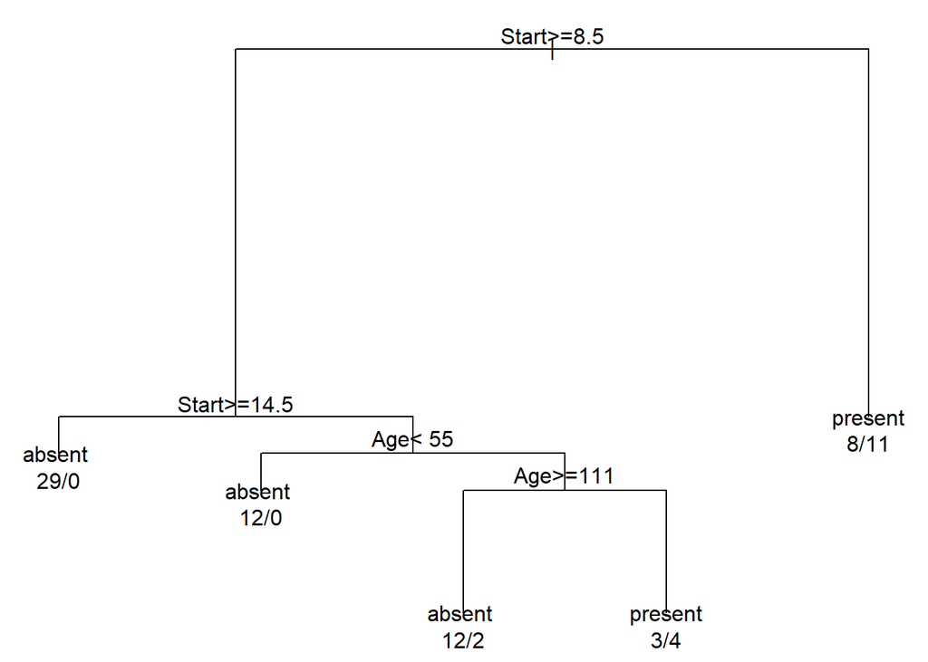

```r
par(mar=c(1,1,1,1), xpd = TRUE); plot(tree.1)
text(tree.1, use.n = TRUE)
```

먼저 불순도지수로 지니지수를 이용할 계획이며, 이에따라 분류를 진행하면 위와 같은 결과를 이끌어낸다. 다음은 불순도 지수로 정보지수(엔트로피) 지수를 사용한 결과이다. 이에따분 분류를 진행하면 아래와 같다.

```r
tree.2 <- rpart(Kyphosis ~ Age + Number + Start, data = kyphosis, parms = list(split = "information"))
tree.2
```

```
## n= 81
##
## node), split, n, loss, yval, (yprob)
##       * denotes terminal node
##
##  1) root 81 17 absent (0.79012346 0.20987654)
##    2) Start>=12.5 46  2 absent (0.95652174 0.04347826) *
##    3) Start< 12.5 35 15 absent (0.57142857 0.42857143)
##      6) Age< 34.5 10  1 absent (0.90000000 0.10000000) *
##      7) Age>=34.5 25 11 present (0.44000000 0.56000000)
##       14) Number< 4.5 12  5 absent (0.58333333 0.41666667) *
##       15) Number>=4.5 13  4 present (0.30769231 0.69230769) *
```

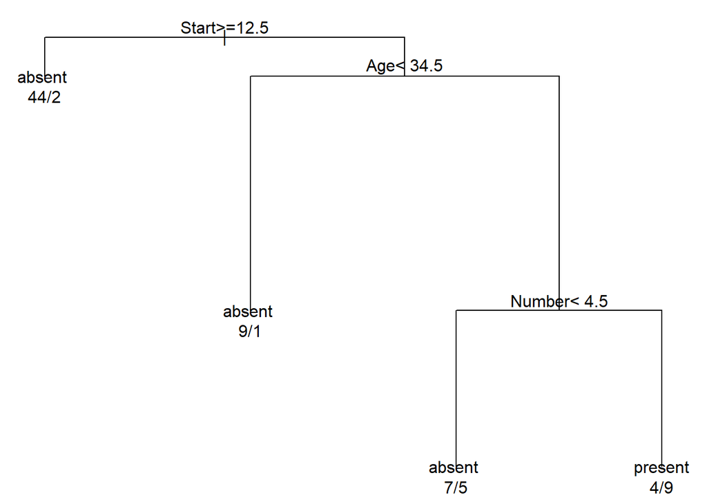

```r
par(mar=c(1,1,1,1), xpd = TRUE); plot(tree.2)
text(tree.2, use.n = TRUE)
```

이때 아래의 결과를 확인하면 전체 오분류에 대해서는 문제가 없지만, 데이터들의 내용에 있어서는 다소 다르다. (보다 구체적으로 false positive와 false negative에 대해서 다르다.)

```r
table(kyphosis$Kyphosis, predict(tree.1, type="class"))
```

```
##
##           absent present
##   absent      53      11
##   present      2      15
```

```r
table(kyphosis$Kyphosis, predict(tree.2, type="class"))
```

```
##
##           absent present
##   absent      60       4
##   present      8       9
```

이는 불균형 데이터에 기반하였기 때문인데, 이를 고려해서 가중치를 다르게 주어 엔트로피 불순도지수를 다시사용해서 모형을 적합시키면 아래와 같이 지니지수와 유사하게 결과를 이끌어 낼 수 있다.

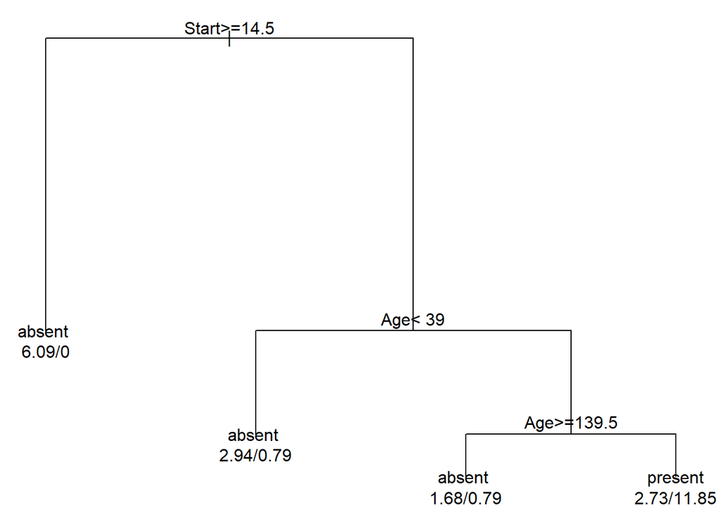

```r
kyphosis$wts <- ifelse(kyphosis$Kyphosis=="present", 0.79, 0.21)

tree.2a <- rpart(Kyphosis ~ Age + Number + Start, data = kyphosis, parms = list(split = "information"), weights=wts)
par(mar=c(1,1,1,1), xpd = TRUE); plot(tree.2a)
text(tree.2a, use.n = TRUE)
```

```r
table(kyphosis$Kyphosis, predict(tree.2a, type="class"))
```

```
##
##           absent present
##   absent      51      13
##   present      2      15
```

### [컴퓨터 성능 사례]

이번에는 cpus자료(회귀) 에 대해 나무모형을 적합해보도록 하자. 먼저 아래의 히스토그램을 보면 심하게 기울어져있는 것을 볼 수 있다. 이에따라 로그변환을 한다.

```r
# bagging for cpus data
data(cpus, package="MASS"); str(cpus)
```

```
## 'data.frame':    209 obs. of  9 variables:
##  $ name   : Factor w/ 209 levels "ADVISOR 32/60",..: 1 3 2 4 5 6 8 9 10 7 ...
##  $ syct   : int  125 29 29 29 29 26 23 23 23 23 ...
##  $ mmin   : int  256 8000 8000 8000 8000 8000 16000 16000 16000 32000 ...
##  $ mmax   : int  6000 32000 32000 32000 16000 32000 32000 32000 64000 64000 ...
##  $ cach   : int  256 32 32 32 32 64 64 64 64 128 ...
##  $ chmin  : int  16 8 8 8 8 8 16 16 16 32 ...
##  $ chmax  : int  128 32 32 32 16 32 32 32 32 64 ...
##  $ perf   : int  198 269 220 172 132 318 367 489 636 1144 ...
##  $ estperf: int  199 253 253 253 132 290 381 381 749 1238 ...
```

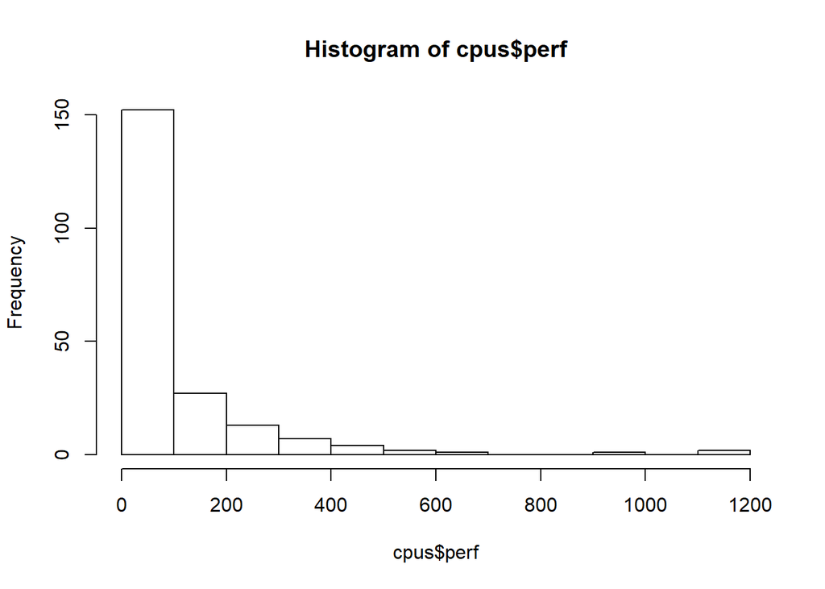

```r
hist(cpus$perf)
```

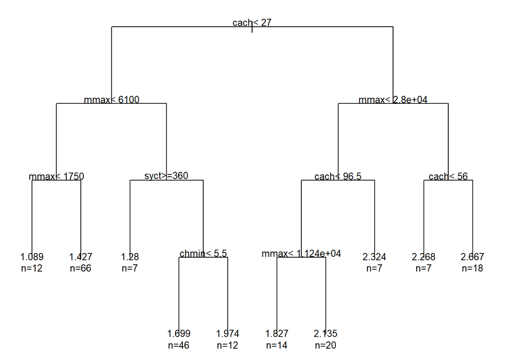

```r
cpus.tree.1 <- rpart(log10(perf) ~ syct+mmin+mmax+cach+chmin+chmax, data=cpus)
windows(height=8,width=8)
par(mar=c(1,1,1,1), xpd = TRUE)
plot(cpus.tree.1, uniform=F)
text(cpus.tree.1, use.n=T, cex=0.8)
```

그리고 나무모형을 적합하면 위와 같다. 이의 평균잔차제곱은 아래에서 확인할 수 있듯 0.03이다.

```r
pred.err <- log10(cpus$perf) - predict(cpus.tree.1)
mean(pred.err*pred.err)
```

```
## [1] 0.03034244
```

그러나, training데이터와 test데이터가 같이 사용되었으므로 이는 부적절하다. 즉, 우리는 복원 추출을 통해 훈련자료를 뽑아내고, 앞에서 뽑히않은 나머지 데이터(oob)를 가지고 모형을 테스트하려고 한다.

```r
subsample <- sample(1:209,replace=T)
cpus.train <- cpus[subsample,]
cpus.test <- cpus[-subsample,]
cpus.tree.1 <- rpart(log10(perf) ~ syct+mmin+mmax+cach+chmin+chmax, data=cpus.train, control = rpart.control(cp=0.02))
pred.err <- log10(cpus.test$perf) - predict(cpus.tree.1,newdata=cpus.test)
mean(pred.err*pred.err)
```

```
## [1] 0.06913134
```

```r
length((1:209)[-subsample])
```

```
## [1] 82
```

이때 sampling 결과에 따라 오분류율이 다르게 나올 수 있지만, 0.03의 값보다는 크게 나타난다. 추가로 위에서 사용한 oob(out of bags)의 셈플수도 확인할 수 있다.

```r
subsample <- sample(1:209,replace=T)
cpus.train <- cpus[subsample,]
cpus.test <- cpus[-subsample,]
cpus.tree.1 <- rpart(log10(perf) ~ syct+mmin+mmax+cach+chmin+chmax, data=cpus.train, control = rpart.control(cp=0.02))
pred.err <- log10(cpus.test$perf) - predict(cpus.tree.1,newdata=cpus.test)
mean(pred.err*pred.err)
```

```
## [1] 0.06545268
```

```r
length((1:209)[-subsample])
```

```
## [1] 78
```

### [배깅(Bagging)]

```r
data(kyphosis); str(kyphosis)
```

```
## 'data.frame':    81 obs. of  4 variables:
##  $ Kyphosis: Factor w/ 2 levels "absent","present": 1 1 2 1 1 1 1 1 1 2 ...
##  $ Age     : int  71 158 128 2 1 1 61 37 113 59 ...
##  $ Number  : int  3 3 4 5 4 2 2 3 2 6 ...
##  $ Start   : int  5 14 5 1 15 16 17 16 16 12 ...
```

```r
kyphosis.present <- kyphosis[kyphosis$Kyphosis=="present",]
kyphosis.absent <- kyphosis[kyphosis$Kyphosis=="absent",]
kyphosis.balanced <- rbind(kyphosis.present, kyphosis.present, kyphosis.present, kyphosis.present, kyphosis.absent)


RF.1 <- randomForest(Kyphosis ~ Age+Number+Start, data=kyphosis.balanced, var.importance=T)
RF.1$importance
```

```
##        MeanDecreaseGini
## Age            21.50072
## Number         12.28571
## Start          25.72043
```

```r
# for cpus
data(cpus)
cpus.bag <- bagging(log10(perf) ~ syct+mmin+mmax+cach+chmin+chmax, data=cpus, coob=T, nbagg=100)
cpus.bag
```

```
##
## Bagging regression trees with 100 bootstrap replications
##
## Call: bagging.data.frame(formula = log10(perf) ~ syct + mmin + mmax +
##     cach + chmin + chmax, data = cpus, coob = T, nbagg = 100)
##
## Out-of-bag estimate of root mean squared error:  0.1966
```

그리고 같은 행위를 cpus 자료(회귀)를 통해 적합시키면 위와 같다. 이 경우는 배깅알고리즘을 회귀로 적용시켜본 결과이다. 그러므로 오분류표는 제공되지 않고, 평균제곱오차 값의 루트값을 제공한다.

### [랜덤포레스트(Random Forest)]

마지막으로 랜덤포레스트에 대해 적용해보자. 랜덤포레스트는 배깅과 유사한데, 배깅 알고리즘을 그대로 따라가다 선택할 변수의 수만 다르게 뽑으면 된다. 또한 위에서 변수 중요도를 확인할 수 있으며, 지니평균감소량(MeanDecreaseGini) 기준에 따라 Start , Age, Number순서로 중요하다.

```r
# for cpus data

data(cpus, package="MASS"); str(cpus)
```

```
## 'data.frame':    209 obs. of  9 variables:
##  $ name   : Factor w/ 209 levels "ADVISOR 32/60",..: 1 3 2 4 5 6 8 9 10 7 ...
##  $ syct   : int  125 29 29 29 29 26 23 23 23 23 ...
##  $ mmin   : int  256 8000 8000 8000 8000 8000 16000 16000 16000 32000 ...
##  $ mmax   : int  6000 32000 32000 32000 16000 32000 32000 32000 64000 64000 ...
##  $ cach   : int  256 32 32 32 32 64 64 64 64 128 ...
##  $ chmin  : int  16 8 8 8 8 8 16 16 16 32 ...
##  $ chmax  : int  128 32 32 32 16 32 32 32 32 64 ...
##  $ perf   : int  198 269 220 172 132 318 367 489 636 1144 ...
##  $ estperf: int  199 253 253 253 132 290 381 381 749 1238 ...
```

```r
RF.2 <- randomForest(log10(perf) ~ syct+mmin+mmax+cach+chmin+chmax, data=cpus,importance=TRUE)
RF.2
```

```
##
## Call:
##  randomForest(formula = log10(perf) ~ syct + mmin + mmax + cach +      chmin + chmax, data = cpus, importance = TRUE)
##                Type of random forest: regression
##                      Number of trees: 500
## No. of variables tried at each split: 2
##
##           Mean of squared residuals: 0.02458457
##                     % Var explained: 88.08
```

그리고 이를 cpus 데이터에 대해 적용하면(회귀) 유사한 결과를 얻는다. 500번 반복으로 통해 얻은 모형의 평균제곱잔차값을 구할 수 있다.

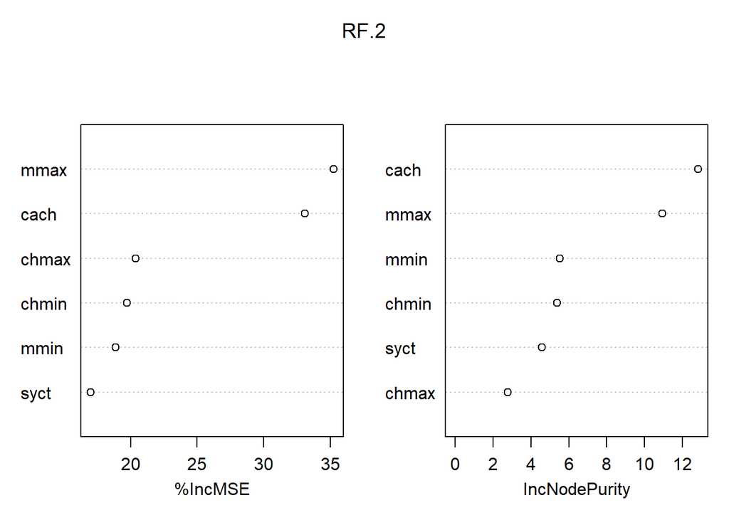

```r
varImpPlot(RF.2)
```